# Introduction to Statistical Learning - Chapter 3

## Question 15

`Boston` dataset is in `MASS` library.

```r
library(MASS)
head(Boston)
```

```
##      crim zn indus chas   nox    rm  age   dis rad tax ptratio black lstat
## 1 0.00632 18  2.31    0 0.538 6.575 65.2 4.090   1 296    15.3 396.9  4.98
## 2 0.02731  0  7.07    0 0.469 6.421 78.9 4.967   2 242    17.8 396.9  9.14
## 3 0.02729  0  7.07    0 0.469 7.185 61.1 4.967   2 242    17.8 392.8  4.03
## 4 0.03237  0  2.18    0 0.458 6.998 45.8 6.062   3 222    18.7 394.6  2.94
## 5 0.06905  0  2.18    0 0.458 7.147 54.2 6.062   3 222    18.7 396.9  5.33
## 6 0.02985  0  2.18    0 0.458 6.430 58.7 6.062   3 222    18.7 394.1  5.21
##   medv
## 1 24.0
## 2 21.6
## 3 34.7
## 4 33.4
## 5 36.2
## 6 28.7
```

Predict using `zn`.

```r
fit = lm(crim~zn, data = Boston)
simple_coefs = coef(fit)[2]
summary(fit)
```

```
##
## Call:
## lm(formula = crim ~ zn, data = Boston)
##
## Residuals:
##    Min     1Q Median     3Q    Max
##  -4.43  -4.22  -2.62   1.25  84.52
##
## Coefficients:
##             Estimate Std. Error t value Pr(>|t|)
## (Intercept)   4.4537     0.4172   10.67  < 2e-16 ***
## zn           -0.0739     0.0161   -4.59  5.5e-06 ***
## ---
## Signif. codes:  0 '***' 0.001 '**' 0.01 '*' 0.05 '.' 0.1 ' ' 1
##
## Residual standard error: 8.44 on 504 degrees of freedom
## Multiple R-squared: 0.0402,  Adjusted R-squared: 0.0383
## F-statistic: 21.1 on 1 and 504 DF,  p-value: 5.51e-06
```

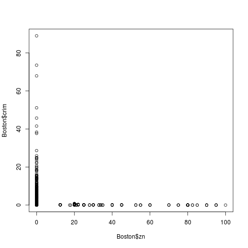

```r
plot(Boston$zn, Boston$crim)
```

Predict using `indus`.

```r
fit = lm(crim~indus, data = Boston)
simple_coefs = c(simple_coefs, coef(fit)[2])
summary(fit)
```

```
##
## Call:
## lm(formula = crim ~ indus, data = Boston)
##
## Residuals:
##    Min     1Q Median     3Q    Max
## -11.97  -2.70  -0.74   0.71  81.81
##
## Coefficients:
##             Estimate Std. Error t value Pr(>|t|)
## (Intercept)   -2.064      0.667   -3.09   0.0021 **
## indus          0.510      0.051    9.99   <2e-16 ***
## ---
## Signif. codes:  0 '***' 0.001 '**' 0.01 '*' 0.05 '.' 0.1 ' ' 1
##
## Residual standard error: 7.87 on 504 degrees of freedom
## Multiple R-squared: 0.165,   Adjusted R-squared: 0.164
## F-statistic: 99.8 on 1 and 504 DF,  p-value: <2e-16
```

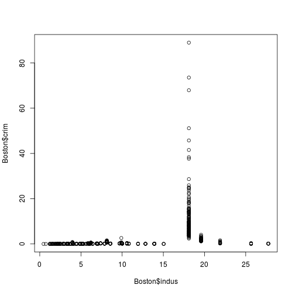

```r
plot(Boston$indus, Boston$crim)
```

Predict using `chas`.

```r
fit = lm(crim~chas, data = Boston)
simple_coefs = c(simple_coefs, coef(fit)[2])
summary(fit)
```

```
##
## Call:
## lm(formula = crim ~ chas, data = Boston)
##
## Residuals:
##    Min     1Q Median     3Q    Max
##  -3.74  -3.66  -3.44   0.02  85.23
##
## Coefficients:
##             Estimate Std. Error t value Pr(>|t|)
## (Intercept)    3.744      0.396    9.45   <2e-16 ***
## chas          -1.893      1.506   -1.26     0.21
## ---
## Signif. codes:  0 '***' 0.001 '**' 0.01 '*' 0.05 '.' 0.1 ' ' 1
##
## Residual standard error: 8.6 on 504 degrees of freedom
## Multiple R-squared: 0.00312, Adjusted R-squared: 0.00115
## F-statistic: 1.58 on 1 and 504 DF,  p-value: 0.209
```

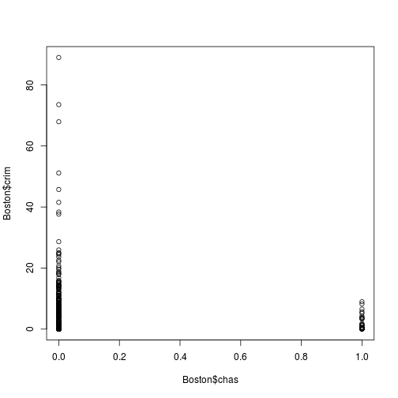

```r
plot(Boston$chas, Boston$crim)
```

Predict using `nox`.

```r
fit = lm(crim~nox, data = Boston)
simple_coefs = c(simple_coefs, coef(fit)[2])
summary(fit)
```

```
##
## Call:
## lm(formula = crim ~ nox, data = Boston)
##
## Residuals:
##    Min     1Q Median     3Q    Max
## -12.37  -2.74  -0.97   0.56  81.73
##
## Coefficients:
##             Estimate Std. Error t value Pr(>|t|)
## (Intercept)    -13.7        1.7   -8.07  5.1e-15 ***
## nox             31.2        3.0   10.42  < 2e-16 ***
## ---
## Signif. codes:  0 '***' 0.001 '**' 0.01 '*' 0.05 '.' 0.1 ' ' 1
##
## Residual standard error: 7.81 on 504 degrees of freedom
## Multiple R-squared: 0.177,   Adjusted R-squared: 0.176
## F-statistic:  109 on 1 and 504 DF,  p-value: <2e-16
```

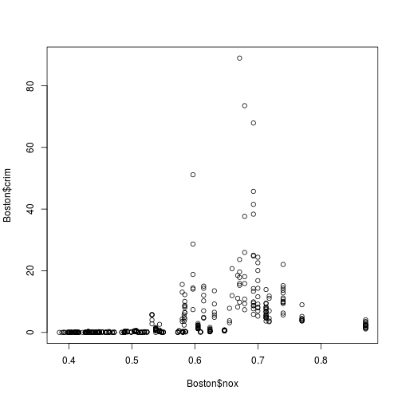

```r
plot(Boston$nox, Boston$crim)
```

Predict using `rm`.

```r
fit = lm(crim~rm, data = Boston)
simple_coefs = c(simple_coefs, coef(fit)[2])
summary(fit)
```

```
##
## Call:
## lm(formula = crim ~ rm, data = Boston)
##
## Residuals:
##    Min     1Q Median     3Q    Max
##  -6.60  -3.95  -2.65   0.99  87.20
##
## Coefficients:
##             Estimate Std. Error t value Pr(>|t|)
## (Intercept)   20.482      3.364    6.09  2.3e-09 ***
## rm            -2.684      0.532   -5.04  6.3e-07 ***
## ---
## Signif. codes:  0 '***' 0.001 '**' 0.01 '*' 0.05 '.' 0.1 ' ' 1
##
## Residual standard error: 8.4 on 504 degrees of freedom
## Multiple R-squared: 0.0481,  Adjusted R-squared: 0.0462
## F-statistic: 25.5 on 1 and 504 DF,  p-value: 6.35e-07
```

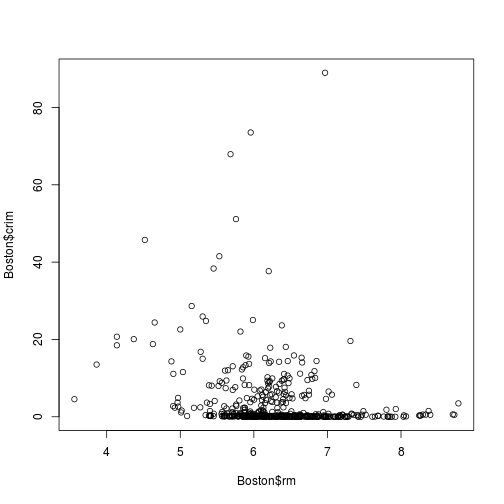

```r
plot(Boston$rm, Boston$crim)
```

Predict using `age`.

```r
fit = lm(crim~age, data = Boston)
simple_coefs = c(simple_coefs, coef(fit)[2])
summary(fit)
```

```
##
## Call:
## lm(formula = crim ~ age, data = Boston)
##
## Residuals:
##    Min     1Q Median     3Q    Max
##  -6.79  -4.26  -1.23   1.53  82.85
##
## Coefficients:
##             Estimate Std. Error t value Pr(>|t|)
## (Intercept)  -3.7779     0.9440   -4.00  7.2e-05 ***
## age           0.1078     0.0127    8.46  2.9e-16 ***
## ---
## Signif. codes:  0 '***' 0.001 '**' 0.01 '*' 0.05 '.' 0.1 ' ' 1
##
## Residual standard error: 8.06 on 504 degrees of freedom
## Multiple R-squared: 0.124,   Adjusted R-squared: 0.123
## F-statistic: 71.6 on 1 and 504 DF,  p-value: 2.85e-16
```

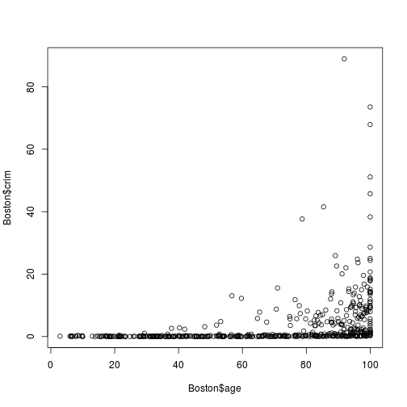

```r
plot(Boston$age, Boston$crim)
```

Predict using `dis`.

```r
fit = lm(crim~dis, data = Boston)
simple_coefs = c(simple_coefs, coef(fit)[2])
summary(fit)
```

```
##
## Call:
## lm(formula = crim ~ dis, data = Boston)
##
## Residuals:
##    Min     1Q Median     3Q    Max
##  -6.71  -4.13  -1.53   1.52  81.67
##
## Coefficients:
##             Estimate Std. Error t value Pr(>|t|)
## (Intercept)    9.499      0.730   13.01   <2e-16 ***
## dis           -1.551      0.168   -9.21   <2e-16 ***
## ---
## Signif. codes:  0 '***' 0.001 '**' 0.01 '*' 0.05 '.' 0.1 ' ' 1
##
## Residual standard error: 7.97 on 504 degrees of freedom
## Multiple R-squared: 0.144,   Adjusted R-squared: 0.142
## F-statistic: 84.9 on 1 and 504 DF,  p-value: <2e-16
```

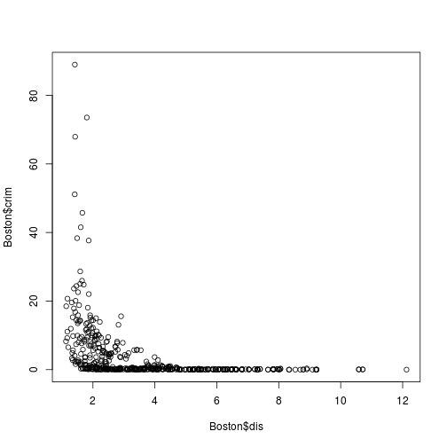

```r
plot(Boston$dis, Boston$crim)
```

Predict using `rad`.

```r
fit = lm(crim~rad, data = Boston)
simple_coefs = c(simple_coefs, coef(fit)[2])
summary(fit)
```

```
##
## Call:
## lm(formula = crim ~ rad, data = Boston)
##
## Residuals:
##    Min     1Q Median     3Q    Max
## -10.16  -1.38  -0.14   0.66  76.43
##
## Coefficients:
##             Estimate Std. Error t value Pr(>|t|)
## (Intercept)  -2.2872     0.4435   -5.16  3.6e-07 ***
## rad           0.6179     0.0343   18.00  < 2e-16 ***
## ---
## Signif. codes:  0 '***' 0.001 '**' 0.01 '*' 0.05 '.' 0.1 ' ' 1
##
## Residual standard error: 6.72 on 504 degrees of freedom
## Multiple R-squared: 0.391,   Adjusted R-squared: 0.39
## F-statistic:  324 on 1 and 504 DF,  p-value: <2e-16
```

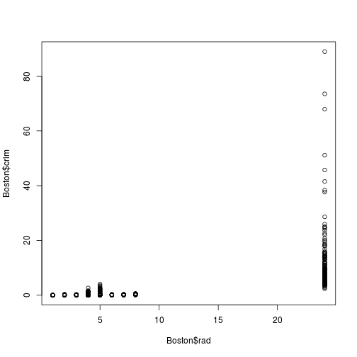

```r
plot(Boston$rad, Boston$crim)
```

Predict using `tax`.

```r
fit = lm(crim~tax, data = Boston)
simple_coefs = c(simple_coefs, coef(fit)[2])
summary(fit)
```

```
##
## Call:
## lm(formula = crim ~ tax, data = Boston)
##
## Residuals:
##    Min     1Q Median     3Q    Max
## -12.51  -2.74  -0.19   1.07  77.70
##
## Coefficients:
##             Estimate Std. Error t value Pr(>|t|)
## (Intercept) -8.52837    0.81581   -10.4   <2e-16 ***
## tax          0.02974    0.00185    16.1   <2e-16 ***
## ---
## Signif. codes:  0 '***' 0.001 '**' 0.01 '*' 0.05 '.' 0.1 ' ' 1
##
## Residual standard error: 7 on 504 degrees of freedom
## Multiple R-squared: 0.34,    Adjusted R-squared: 0.338
## F-statistic:  259 on 1 and 504 DF,  p-value: <2e-16
```

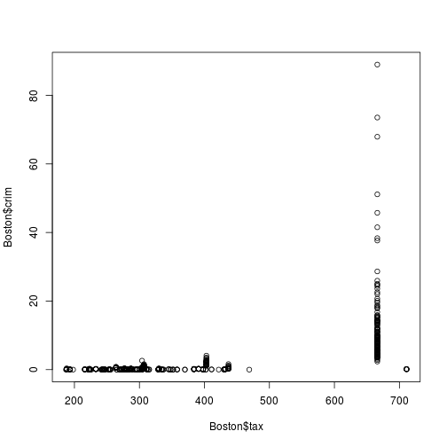

```r
plot(Boston$tax, Boston$crim)
```

Predict using `ptratio`.

```r
fit = lm(crim~ptratio, data = Boston)
simple_coefs = c(simple_coefs, coef(fit)[2])
summary(fit)
```

```
##
## Call:
## lm(formula = crim ~ ptratio, data = Boston)
##
## Residuals:
##    Min     1Q Median     3Q    Max
##  -7.65  -3.99  -1.91   1.82  83.35
##
## Coefficients:
##             Estimate Std. Error t value Pr(>|t|)
## (Intercept)  -17.647      3.147   -5.61  3.4e-08 ***
## ptratio        1.152      0.169    6.80  2.9e-11 ***
## ---
## Signif. codes:  0 '***' 0.001 '**' 0.01 '*' 0.05 '.' 0.1 ' ' 1
##
## Residual standard error: 8.24 on 504 degrees of freedom
## Multiple R-squared: 0.0841,  Adjusted R-squared: 0.0823
## F-statistic: 46.3 on 1 and 504 DF,  p-value: 2.94e-11
```

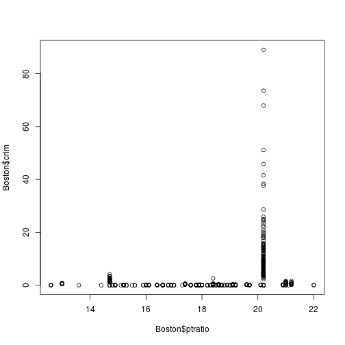

```r
plot(Boston$ptratio, Boston$crim)
```

Predict using `black`.

```r
fit = lm(crim~black, data = Boston)
simple_coefs = c(simple_coefs, coef(fit)[2])
summary(fit)
```

```
##
## Call:
## lm(formula = crim ~ black, data = Boston)
##
## Residuals:
##    Min     1Q Median     3Q    Max
## -13.76  -2.30  -2.09  -1.30  86.82
##
## Coefficients:
##             Estimate Std. Error t value Pr(>|t|)
## (Intercept) 16.55353    1.42590   11.61   <2e-16 ***
## black       -0.03628    0.00387   -9.37   <2e-16 ***
## ---
## Signif. codes:  0 '***' 0.001 '**' 0.01 '*' 0.05 '.' 0.1 ' ' 1
##
## Residual standard error: 7.95 on 504 degrees of freedom
## Multiple R-squared: 0.148,   Adjusted R-squared: 0.147
## F-statistic: 87.7 on 1 and 504 DF,  p-value: <2e-16
```

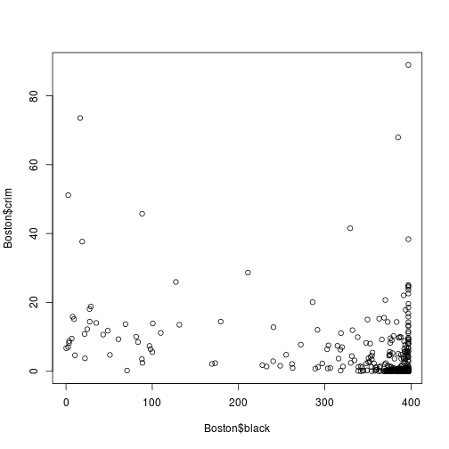

```r
plot(Boston$black, Boston$crim)
```

Predict using `lstat`.

```r
fit = lm(crim~lstat, data = Boston)
simple_coefs = c(simple_coefs, coef(fit)[2])
summary(fit)
```

```
##
## Call:
## lm(formula = crim ~ lstat, data = Boston)
##
## Residuals:
##    Min     1Q Median     3Q    Max
## -13.93  -2.82  -0.66   1.08  82.86
##
## Coefficients:
##             Estimate Std. Error t value Pr(>|t|)
## (Intercept)  -3.3305     0.6938    -4.8  2.1e-06 ***
## lstat         0.5488     0.0478    11.5  < 2e-16 ***
## ---
## Signif. codes:  0 '***' 0.001 '**' 0.01 '*' 0.05 '.' 0.1 ' ' 1
##
## Residual standard error: 7.66 on 504 degrees of freedom
## Multiple R-squared: 0.208,   Adjusted R-squared: 0.206
## F-statistic:  132 on 1 and 504 DF,  p-value: <2e-16
```

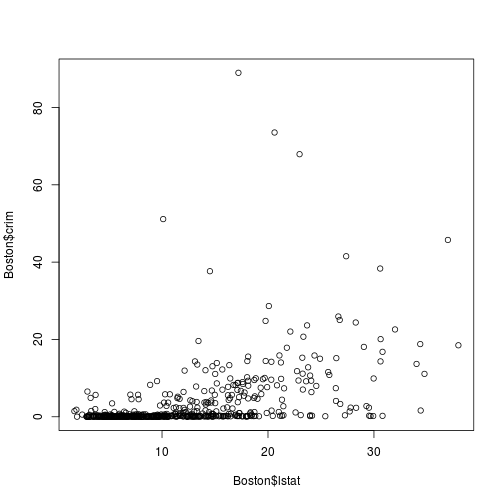

```r
plot(Boston$lstat, Boston$crim)
```

Predict using `medv`.

```r
fit = lm(crim~medv, data = Boston)
simple_coefs = c(simple_coefs, coef(fit)[2])
summary(fit)
```

```
##
## Call:
## lm(formula = crim ~ medv, data = Boston)
##
## Residuals:
##    Min     1Q Median     3Q    Max
##  -9.07  -4.02  -2.34   1.30  80.96
##
## Coefficients:
##             Estimate Std. Error t value Pr(>|t|)
## (Intercept)  11.7965     0.9342   12.63   <2e-16 ***
## medv         -0.3632     0.0384   -9.46   <2e-16 ***
## ---
## Signif. codes:  0 '***' 0.001 '**' 0.01 '*' 0.05 '.' 0.1 ' ' 1
##
## Residual standard error: 7.93 on 504 degrees of freedom
## Multiple R-squared: 0.151,   Adjusted R-squared: 0.149
## F-statistic: 89.5 on 1 and 504 DF,  p-value: <2e-16
```

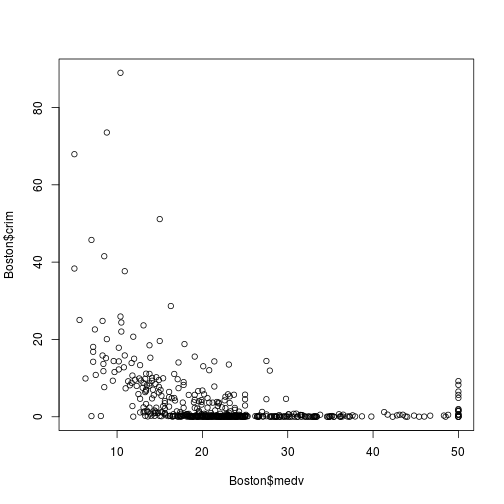

```r
plot(Boston$medv, Boston$crim)
```

Looked at individually, all of the predictors seem to be related to output except `chas`.

Fit a multiple linear regression model with all the predictors.

```r
fit = lm(crim~., data = Boston)
multi_coefs = coef(fit)[-1]
summary(fit)
```

```
##
## Call:
## lm(formula = crim ~ ., data = Boston)
##
## Residuals:
##    Min     1Q Median     3Q    Max
##  -9.92  -2.12  -0.35   1.02  75.05
##
## Coefficients:
##              Estimate Std. Error t value Pr(>|t|)
## (Intercept)  17.03323    7.23490    2.35   0.0189 *
## zn            0.04486    0.01873    2.39   0.0170 *
## indus        -0.06385    0.08341   -0.77   0.4443
## chas         -0.74913    1.18015   -0.63   0.5259
## nox         -10.31353    5.27554   -1.95   0.0512 .
## rm            0.43013    0.61283    0.70   0.4831
## age           0.00145    0.01793    0.08   0.9355
## dis          -0.98718    0.28182   -3.50   0.0005 ***
## rad           0.58821    0.08805    6.68  6.5e-11 ***
## tax          -0.00378    0.00516   -0.73   0.4638
## ptratio      -0.27108    0.18645   -1.45   0.1466
## black        -0.00754    0.00367   -2.05   0.0407 *
## lstat         0.12621    0.07572    1.67   0.0962 .
## medv         -0.19889    0.06052   -3.29   0.0011 **
## ---
## Signif. codes:  0 '***' 0.001 '**' 0.01 '*' 0.05 '.' 0.1 ' ' 1
##
## Residual standard error: 6.44 on 492 degrees of freedom
## Multiple R-squared: 0.454,   Adjusted R-squared: 0.44
## F-statistic: 31.5 on 13 and 492 DF,  p-value: <2e-16
```

Now, for many of the predictors the relations are not significant anymore.

Plot coefficients from simple models versus the coefficients from multiple linear regression.

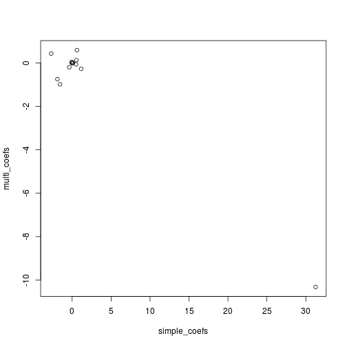

```r
plot(simple_coefs, multi_coefs)
```